# 最終レポート

### 4.4.2 group2

```r
# 共起を調べる
g2res <- collocate("/home/2024A/tm005/R_analysis/最終発表/lyrics_doc123/g2_lyrics.txt", node = "君", span = 3)
```

```
file = /home/2024A/tm005/R_analysis/最終発表/lyrics_doc123/g2_lyrics.txt
length = 1417
```

```r
# T値とMI値を求める
g2res2 <- collScores(g2res, node = "君", span = 3)
g2res2 %>% tail(10)
```

```
            Term Before After Span Total          T         MI
228         関係      1     0    1     2  0.7981393  2.3085678
229         降る      1     0    1     4  0.5962785  1.3085678
230           隣      0     1    1     3  0.6972089  1.7236053
231       離れる      1     1    2     4  1.1287394  2.3085678
232           雨      1     0    1     7  0.2934875  0.5012129
233       震える      1     0    1     3  0.6972089  1.7236053
234           顔      0     2    2     9  0.7718967  1.1386428
235           ？      1     0    1    12 -0.2111644 -0.2763947
236 [[MORPHEMS]]    133   102  235  1417         NA         NA
237   [[TOKENS]]    716   537 1253 10641         NA         NA
```

```r
# T値が1.65以上、MI値が1.58以上のものをフィルタリング
g2res3 <- g2res2 %>%
  filter(T >= 1.65, MI >= 1.58)

# 結果を表示
print(g2res3)
```

```
        Term Before After Span Total        T       MI
21      けど     10     0   10    29 2.236685 1.772515
65      など      0     4    4     5 1.747674 2.986640
69  なんとか      6     0    6     6 2.202262 3.308568
110 サイレン      4     0    4     4 1.798139 3.308568
126   代わり      0     4    4     4 1.798139 3.308568
193       為      0     6    6    14 1.872625 2.086175
200     笑う      4     9   13    26 2.877732 2.308568
```

### 4.4.3 group3

```r
# 共起を調べる
g1res <- collocate("/home/2024A/tm005/R_analysis/最終発表/lyrics_doc123/g3_lyrics.txt", node = "君", span = 3)
```

```
file = /home/2024A/tm005/R_analysis/最終発表/lyrics_doc123/g3_lyrics.txt
length = 1732
```

```r
# T値とMI値を求める
g3res2 <- collScores(g1res, node = "君", span = 3)
g3res2 %>% tail(10)
```

```
            Term Before After Span Total           T         MI
288           音      1     0    1     9  0.08633859  0.1302685
289           頭      2     1    3     4  1.49760518  2.8851560
290           顔      0     1    1     7  0.28937446  0.4928385
291     飛び出す      0     1    1     3  0.69544620  1.7152310
292   飛び越える      2     0    2     2  1.27064552  3.3001935
293         馬鹿      1     0    1     6  0.39089239  0.7152310
294           ！      2     2    4    13  1.34013342  1.5997538
295           ？      1     0    1    15 -0.52276902 -0.6066971
296 [[MORPHEMS]]    166   129  295  1732          NA         NA
297   [[TOKENS]]    700   525 1225 10343          NA         NA
```

```r
# T値が1.65以上、MI値が1.58以上のものをフィルタリング
g3res3 <- g3res2 %>%
  filter(T >= 1.65, MI >= 1.58)

# 結果を表示
print(g3res3)
```

```
      Term Before After Span Total        T       MI
46  そして      5     0    5     6 1.963667 3.037159
98  もしも      4     0    4     4 1.796964 3.300193
137   全部      3     3    6    19 1.662044 1.637228
247   笑顔      0     5    5     7 1.918267 2.814767
```

- group2と3では「笑う」や「笑顔」などの言葉が共起語として提案された。清水氏における、ここ10年のホットワードなのかもしれない。
- 続いては、N-gramを用いて語の間の関係について分析を深める。

## 4.5 N-gram

### 4.5.1 group1

```r
# N-gramの作成
g1bigram <- NgramDF("/home/2024A/tm005/R_analysis/最終発表/lyrics_doc123/g1_lyrics.txt", type = 1, pos = c("名詞", "形容詞", "動詞"), N = 2)
```

```
file = /home/2024A/tm005/R_analysis/最終発表/lyrics_doc123/g1_lyrics.txt Ngram = 2
```

```r
# 「君」を含むN-gramの抽出
g1bigram2 <- g1bigram[grepl("君", g1bigram$Ngram1) | grepl("君", g1bigram$Ngram2), ]

# 結果を確認する
head(g1bigram2)
```

```
    Ngram1 Ngram2 Freq
7        ?     君    1
71    いい     君    3
87    いく     君    5
109   いつ     君    1
150   いる     君    5
212   お昼     君    1
```

### 4.5.2 group2

```r
# N-gramの作成
g2bigram <- NgramDF("/home/2024A/tm005/R_analysis/最終発表/lyrics_doc123/g2_lyrics.txt", type = 1, pos = c("名詞", "形容詞", "動詞"), N = 2)
```

```
file = /home/2024A/tm005/R_analysis/最終発表/lyrics_doc123/g2_lyrics.txt Ngram = 2
```

```r
# 「君」を含むN-gramの抽出
g2bigram2 <- g2bigram[grepl("君", g2bigram$Ngram1) | grepl("君", g2bigram$Ngram2), ]

# 結果を確認する
head(g2bigram2)
```

```
    Ngram1 Ngram2 Freq
63    いい     君    1
80    いく     君    1
97    いつ     君    1
143   いる     君    2
204   かい     君    1
242   くる     君    1
```

### 4.5.3 group3

```r
# N-gramの作成
g3bigram <- NgramDF("/home/2024A/tm005/R_analysis/最終発表/lyrics_doc123/g3_lyrics.txt", type = 1, pos = c("名詞", "形容詞", "動詞"), N = 2)
```

```
file = /home/2024A/tm005/R_analysis/最終発表/lyrics_doc123/g3_lyrics.txt Ngram = 2
```

```r
# 「君」を含むN-gramの抽出
g3bigram2 <- g3bigram[grepl("君", g3bigram$Ngram1) | grepl("君", g3bigram$Ngram2), ]

# 結果を確認する
head(g3bigram2)
```

```
      Ngram1 Ngram2 Freq
37  あかつき     君    1
84      ある     君    2
141   いつか     君    2
146   いとこ     君    1
183     いる     君    1
226   おいで     君    1
```

- 以下のようことがわかった。
  - いる+君というパターンがどのgroupにおいても存在する。
  - 「〜している君」のように、相手の動作を表す表現が多いのだと考えられ、過去の思い出を連想させる歌詞が多いからではないかと考えられる。
  - よって、使われ方においてもある程度リリース時期に関わらず類似性が見られた。
- ここから先では、言葉単位よりも更にマクロに楽曲間の比較を行うため、クラスター分析やトピックモデルによる分析を行った。

## 4.6 クラスター分析 （参考：教科書と生成AI）

### 4.6.1 lyrics_doc2 (リリース時期をファイル名とする歌詞テキストファイル) の作成

```r
artist <- read.csv("~/R_analysis/artist_df.csv", sep = ",")

# 作詞者が清水依与吏のものだけを抽出
artist <- artist %>% filter(Lyricist == "清水依与吏")

# 保存先ディレクトリを定義
output_dir <- "lyrics_doc2"

# ディレクトリが存在しない場合は作成
if (!dir.exists(output_dir)) {
  dir.create(output_dir, recursive = TRUE)
}

# 例として、ファイル名に使用する文字列を安全なものにする関数（sanitize_filename）
sanitize_filename <- function(x) {
  # ここではシンプルに、スラッシュやスペースをハイフンに変換する例
  x <- gsub("[/\\s]", "-", x)
  x
}

# 歌詞データを一曲ずつ保存する
for (i in 1:nrow(artist)) {
  # 曲名の代わりにリリース日を用いてファイル名のベースを生成
  base_filename <- sanitize_filename(artist$Release_Date[i])
  filename <- paste0(base_filename, ".txt")

  # フルパスを生成
  filepath <- file.path(output_dir, filename)

  # 同じファイル名が既に存在する場合、末尾に _1, _2, … を追加する
  counter <- 1
  while(file.exists(filepath)) {
    filename <- paste0(base_filename, "_", counter, ".txt")
    filepath <- file.path(output_dir, filename)
    counter <- counter + 1
  }

  # 歌詞を指定ディレクトリに保存
  writeLines(artist$Lyric[i], filepath, useBytes = TRUE)
}
```

### 4.6.2 デンドログラム (全体) の表示

```r
library(RMeCab)
library(stringr)
library(dplyr)
library(magrittr)
library(ggdendro)
library(dendextend)
# 1. データ読み込みとクラスタリング
prime2 <- docMatrix2("/home/2024A/tm005/R_analysis/最終発表/lyrics_doc2",
                      pos = c("名詞", "形容詞", "動詞"),
                      weight = "tf*idf*norm")
```

[output not shown]

[output cut: 67 more lines]

```
file_name =  /home/2024A/tm005/R_analysis/最終発表/lyrics_doc2/2021-09-29.txt opened
file_name =  /home/2024A/tm005/R_analysis/最終発表/lyrics_doc2/2022-08-26.txt opened
file_name =  /home/2024A/tm005/R_analysis/最終発表/lyrics_doc2/2022-10-24.txt opened
file_name =  /home/2024A/tm005/R_analysis/最終発表/lyrics_doc2/2023-01-17_1.txt opened
file_name =  /home/2024A/tm005/R_analysis/最終発表/lyrics_doc2/2023-01-17_2.txt opened
file_name =  /home/2024A/tm005/R_analysis/最終発表/lyrics_doc2/2023-01-17_3.txt opened
file_name =  /home/2024A/tm005/R_analysis/最終発表/lyrics_doc2/2023-01-17_4.txt opened
file_name =  /home/2024A/tm005/R_analysis/最終発表/lyrics_doc2/2023-01-17_5.txt opened
file_name =  /home/2024A/tm005/R_analysis/最終発表/lyrics_doc2/2023-01-17.txt opened
file_name =  /home/2024A/tm005/R_analysis/最終発表/lyrics_doc2/2023-08-04.txt opened
file_name =  /home/2024A/tm005/R_analysis/最終発表/lyrics_doc2/2024-01-24.txt opened
file_name =  /home/2024A/tm005/R_analysis/最終発表/lyrics_doc2/2024-07-15.txt opened
file_name =  /home/2024A/tm005/R_analysis/最終発表/lyrics_doc2/2024-09-11.txt opened
number of extracted terms = 2500
to make matrix now
```

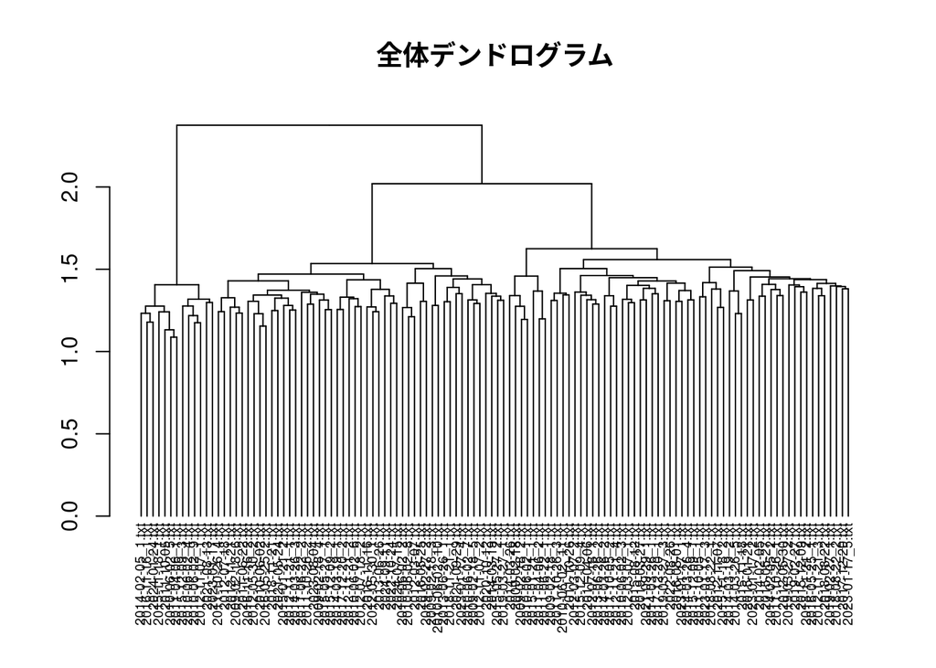

```r
hc <- prime2 %>% t %>% dist %>% hclust("ward.D2")

# 2. 全体のデンドログラムの作成
dend_all <- as.dendrogram(hc)

# ラベルサイズを変更（dendextend を使って調整）
dend_all <- set(dend_all, "labels_cex", 0.6)

# 全体のデンドログラムを表示
plot(dend_all, main = "全体デンドログラム")
```

- 文字が潰れていて分析しづらいため、サブツリーを生成する。

### 4.6.3 サブツリーの生成

```r
# 3. 指定した高さでデンドログラムをカットしてサブツリーを取得
cut_tree <- cut(dend_all, h = 1.5)  # 高さ 50 でカット（適宜変更）
num_parts <- length(cut_tree$lower)
cat("取得できたサブツリーの数：", num_parts, "\n")
```

```
取得できたサブツリーの数： 9
```

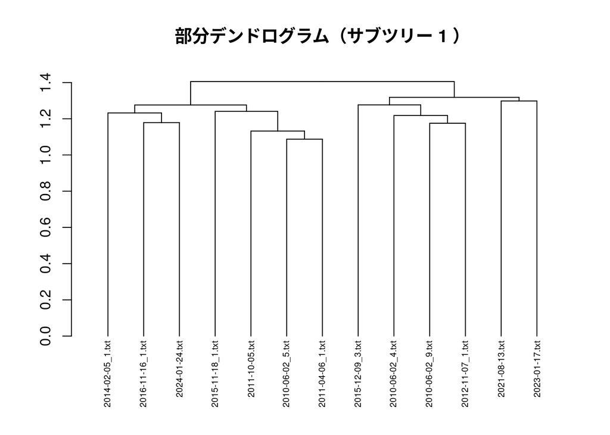

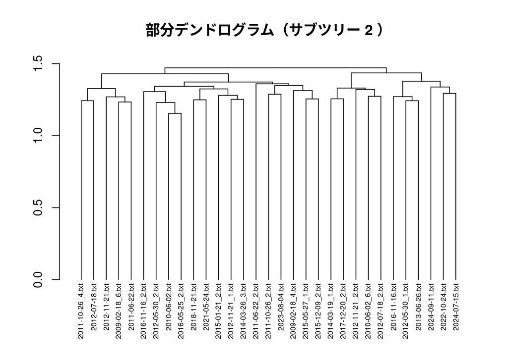

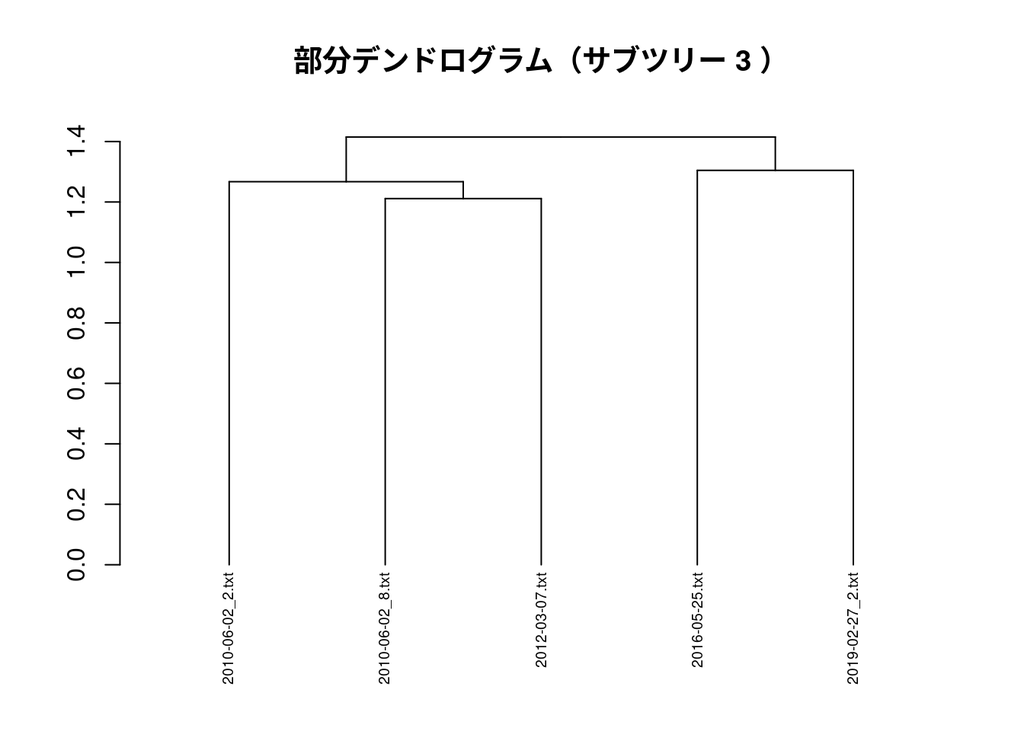

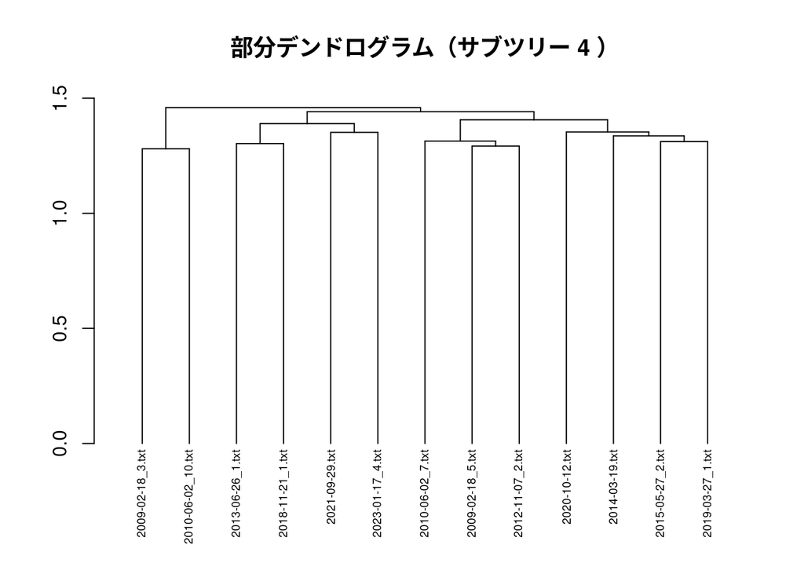

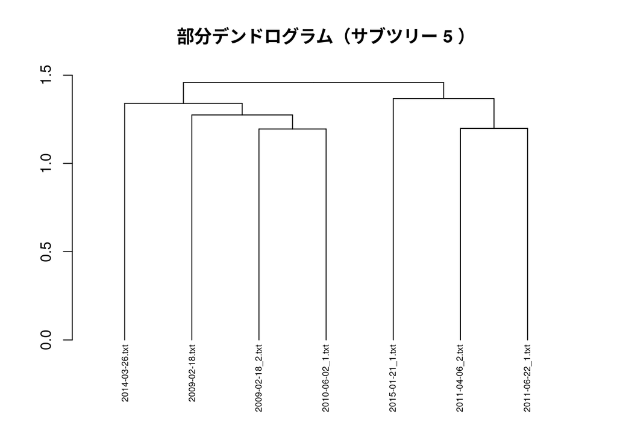

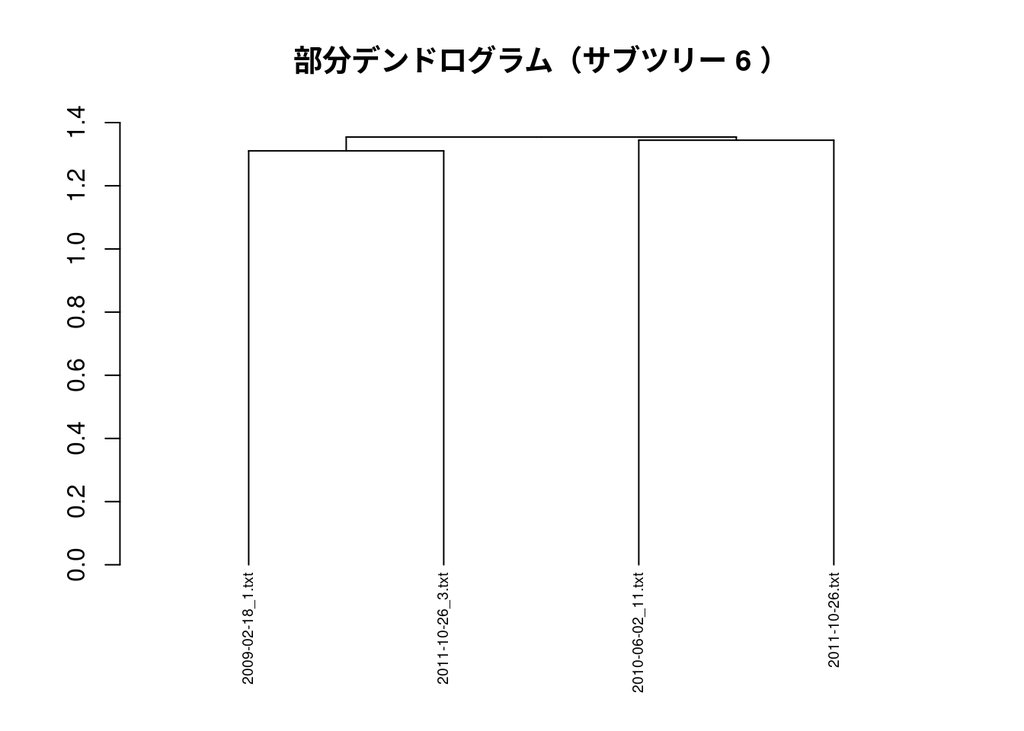

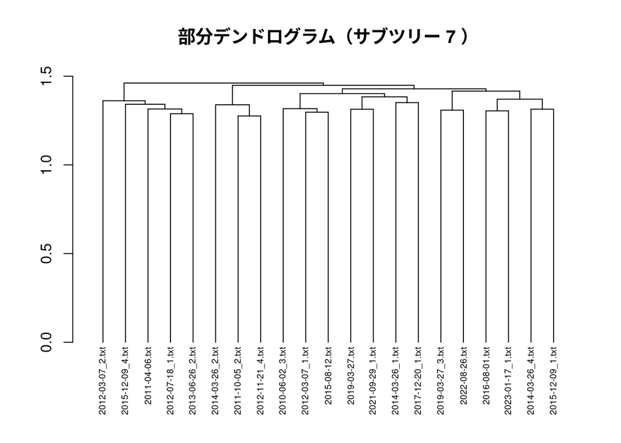

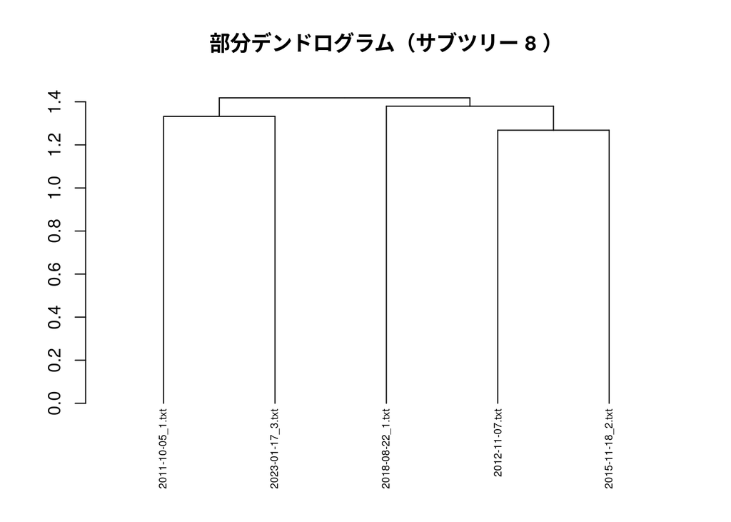

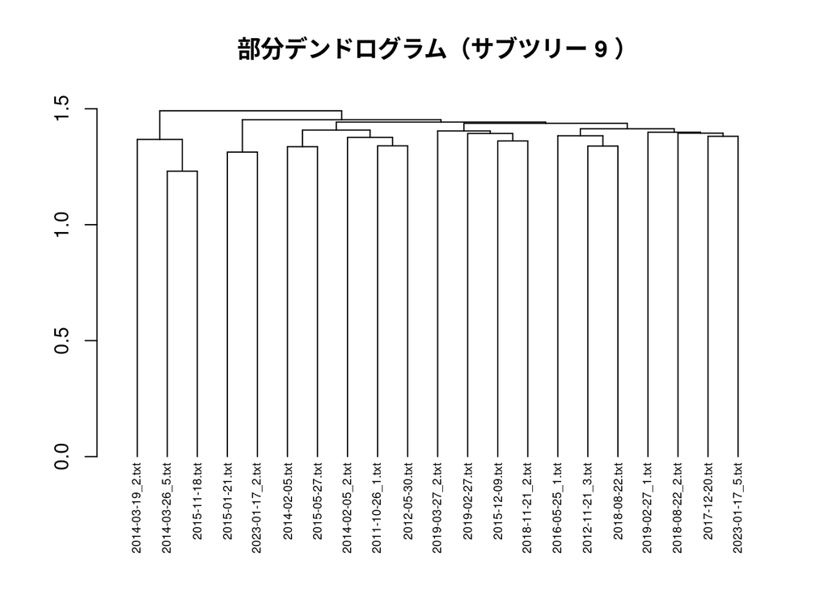

```r
# 4. 各サブツリーを個別に表示（サブツリーにもラベルサイズ設定を適用）
for(i in seq_len(num_parts)) {
  subtree <- cut_tree$lower[[i]]
  subtree <- set(subtree, "labels_cex", 0.6)  # ラベルサイズを変更
  plot(subtree, main = paste("部分デンドログラム（サブツリー", i, "）"))
}
```

- 年代が近い曲の集まるサブツリーもいくつかあるが、全体としてはそこまではっきりと分かれなかった。
- tf-idfでは単語の頻度のみしか考慮できていないため、続いてはトピックモデルによって共起度を評価に含めた分析を行う。

## 4.7 トピックモデル (参考：教科書と生成AI)

### 4.7.1 lyrics_doc (リリース時期と曲名をファイル名とする歌詞テキストファイル) の作成

```r
artist <- read.csv("~/R_analysis/artist_df.csv", sep = ",")

# 作詞者が清水依与吏のものだけを抽出
artist <- artist %>% filter(Lyricist == "清水依与吏")
artist$SongName <- paste(artist$Release_Date, artist$SongName, sep = "_")

#artist

# 保存先ディレクトリを定義
output_dir <- "lyrics_doc"

# ディレクトリが存在しない場合は作成
if (!dir.exists(output_dir)) {
  dir.create(output_dir, recursive = TRUE)
}

# 歌詞データを一曲ずつ保存する
for (i in 1:nrow(artist)) {
  # 曲名を用いてファイル名を生成
  filename <- paste0(sanitize_filename(artist$SongName[i]), ".txt")

  # フルパスを生成
  filepath <- file.path(output_dir, filename)

  # 歌詞を指定ディレクトリに保存
  writeLines(artist$Lyric[i], filepath, useBytes = TRUE)
}
```

### 4.7.2 トピックモデル生成

```r
# トピックモデル
#install.packages(c("topicmodels","lda"))

library(RMeCab)
library(dplyr)
library(stringr)
library(magrittr)
library(tm)
# 形態素解析によりデータフレームを作成
prime <- docDF("/home/2024A/tm005/R_analysis/最終発表/lyrics_doc",
               type = 1,
               pos = c("動詞","名詞","形容詞"),
               minFreq = 1)
```

[output not shown]

[output cut: 67 more lines]

```
file_name =  /home/2024A/tm005/R_analysis/最終発表/lyrics_doc/2021-09-29_黄色.txt opened
file_name =  /home/2024A/tm005/R_analysis/最終発表/lyrics_doc/2022-08-26_ベルベットの詩.txt opened
file_name =  /home/2024A/tm005/R_analysis/最終発表/lyrics_doc/2022-10-24_アイラブユー.txt opened
file_name =  /home/2024A/tm005/R_analysis/最終発表/lyrics_doc/2023-01-17_Silent Journey in Tokyo.txt opened
file_name =  /home/2024A/tm005/R_analysis/最終発表/lyrics_doc/2023-01-17_ゴールデンアワー.txt opened
file_name =  /home/2024A/tm005/R_analysis/最終発表/lyrics_doc/2023-01-17_ヒーロースーツ.txt opened
file_name =  /home/2024A/tm005/R_analysis/最終発表/lyrics_doc/2023-01-17_添い寝チャンスは突然に.txt opened
file_name =  /home/2024A/tm005/R_analysis/最終発表/lyrics_doc/2023-01-17_秘密のキス.txt opened
file_name =  /home/2024A/tm005/R_analysis/最終発表/lyrics_doc/2023-01-17_赤い花火.txt opened
file_name =  /home/2024A/tm005/R_analysis/最終発表/lyrics_doc/2023-08-04_怪獣のサイズ.txt opened
file_name =  /home/2024A/tm005/R_analysis/最終発表/lyrics_doc/2024-01-24_冬と春.txt opened
file_name =  /home/2024A/tm005/R_analysis/最終発表/lyrics_doc/2024-07-15_新しい恋人達に.txt opened
file_name =  /home/2024A/tm005/R_analysis/最終発表/lyrics_doc/2024-09-11_楽園の地図.txt opened
number of extracted terms = 2599
now making a data frame. wait a while!
```

```r
# データの次元確認
dim(prime)
```

```
[1] 2599  123
```

```r
# ストップワードの定義
stop_words <- c("する", "それ", "なる", "ない", "そこ", "これ", "ある", "(", ")")

# ストップワードの除去、特定のPOS2を除外
prime22 <- prime %>%
  # TERMがstop_wordsに含まれない行を抽出
  filter(!(TERM %in% stop_words)) %>%
  # POS2が「非自立」「接尾」「数」でない行を抽出
  filter(!(POS2 %in% c("非自立", "接尾", "数")))

# 結果の次元を確認
dim(prime22)
```

```
[1] 2364  123
```

```r
# 重複しているTERMの位置を確認
which(duplicated(prime22$TERM))
```

```
 [1]   10   23  284  341  511  513  522  538  702  932  976 1068 1496 1513 1557
```

```r
## 数値列だけを残したオブジェクトを作成
prime3 <- prime22 %>% select(-c(TERM:POS2))

## 行名に形態素解析の結果（TERM）を設定（重複を解消）
rownames(prime3) <- make.unique(prime22$TERM)

## ターム文書行列（Document-Term Matrix）の作成
prime3a <- prime3 %>% t() %>% as.DocumentTermMatrix(weighting = weightTf)
```

### 4.7.3 LDA

```r
# トピックモデルによるモデル推定
library(topicmodels)
## トピックの数を指定
K <- 5
res1 <- prime3a %>% LDA(K, control = list(initialize = "seeded",
                                          seed=123))
```

```
initialized with document 69
initialized with document 4
initialized with document 9
initialized with document 46
initialized with document 39
```

```r
terms(res1)
```

```
 Topic 1  Topic 2  Topic 3  Topic 4  Topic 5
    "君" "あなた"     "誰"     "君"     "君"
```

```r
str(res1)
```

[output not shown]

```
      [,1]     [,2]     [,3]     [,4]     [,5]
 [1,] "僕"     "君"     "自分"   "あなた" "誰"
 [2,] "君"     "僕"     "君"     "私"     "今日"
 [3,] "街"     "言う"   "世界"   "好き"   "僕ら"
 [4,] "変わる" "いる"   "どこ"   "言う"   "自分"
 [5,] "何"     "思う"   "人生"   "気付く" "無い"
 [6,] "見える" "いい"   "星"     "離す"   "人"
 [7,] "誰"     "気持ち" "全部"   "涙"     "優しい"
 [8,] "忘れる" "言える" "生きる" "手"     "踊る"
 [9,] "空"     "胸"     "頭"     "見る"   "意味"
[10,] "歩く"   "何"     "事"     "夏"     "歌う"
[11,] "声"     "行く"   "未来"   "強い"   "光"
[12,] "綺麗"   "どこ"   "となり" "電話"   "ゆう"
[13,] "誰か"   "笑う"   "怖い"   "恋"     "見せる"
[14,] "心"     "明日"   "考える" "顔"     "雪"
[15,] "思う"   "目"     "毎日"   "出る"   "前"
[16,] "前"     "最後"   "教える" "横"     "いい"
[17,] "日々"   "待つ"   "絵"     "春"     "笑う"
[18,] "目"     "大丈夫" "愛"     "幸せ"   "すべて"
[19,] "走る"   "今"     "笑顔"   "他"     "悲しい"
[20,] "風"     "嫌"     "色"     "嬉しい" "知る"
```

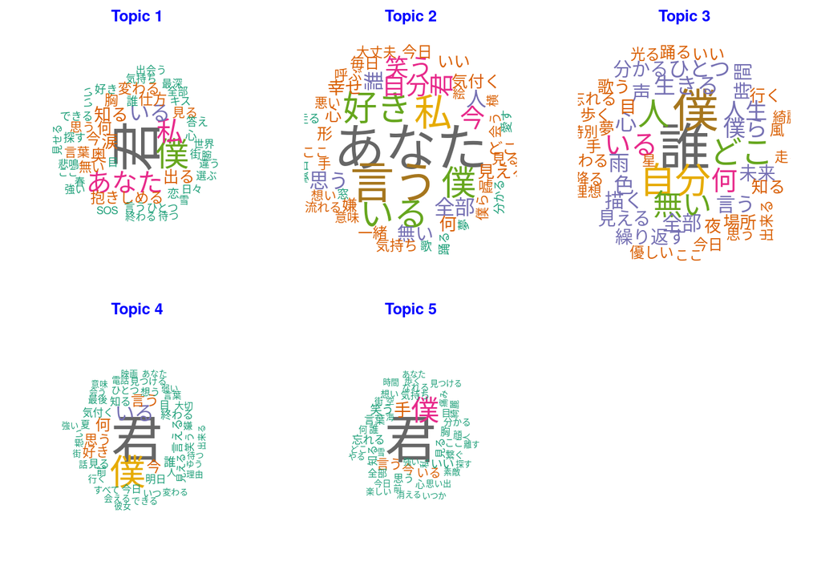

```r
#posterior(res1)[[1]] [1:5,1:5]
#posterior(res1)[[2]]


# ldaパッケージによる分析と可視化
prime4  <- dtm2ldaformat(prime3a)

library(lda)
set.seed(123)
K <- 5
result <- lda.collapsed.gibbs.sampler(prime4$documents, K = K,
            prime4$vocab, 25, 0.1, 0.1, compute.log.likelihood=TRUE)

library(wordcloud)
library(RColorBrewer)

# LDA の結果から各トピックごとの単語確率を取得
word_probs <- posterior(res1)$terms  # res1 は LDA の結果

# プロット領域を広げる（エラー対策）
par(mfrow = c(2, 3), mar = c(2, 2, 2, 2))  # 横 3, 縦 2 のレイアウト

# シード値を設定して毎回同じ配置に
set.seed(123)

# 各トピックごとに wordcloud を作成
for (k in 1:K) {
  # トピック k の単語確率を取得
  topic_probs <- word_probs[k, ]  # トピック k の確率分布

  # 出現確率が高い順に並べて、上位 50 語を取得
  top_words <- names(sort(topic_probs, decreasing = TRUE))[1:50]
  top_freqs <- sort(topic_probs, decreasing = TRUE)[1:50]

  # wordcloud のプロット
  wordcloud(words = top_words, freq = top_freqs, min.freq = 0,
            colors = brewer.pal(8, "Dark2"), scale = c(4, 0.5),
            random.order = FALSE, fixed.asp = TRUE)

  # トピック番号を表示
  title(main = paste("Topic", k), col.main = "blue", font.main = 2)
}

# 上位20語の表示
top.topic.words(result$topics, 20, by.score=TRUE)
```

```r
# トピックごとの曲数をカウント
document_topics <- topics(res1)
topic_count <- table(document_topics)

# 結果の表示
topic_count
```

```
document_topics
 1  2  3  4  5
23 22 25 30 20
```

### 4.7.4 t-SNEによる図示

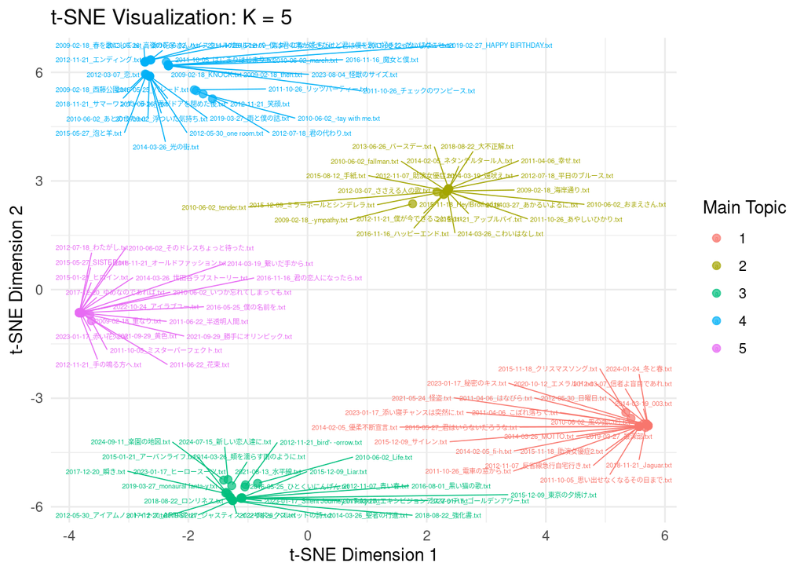

```r
library(Rtsne)       # t-SNE
library(ggplot2)     # 可視化
library(dplyr)       # データ処理
library(topicmodels) # トピックモデル
library(lda)         # LDA


# トピック分布（曲ごとのトピック所属確率）を取得
topic_probabilities <- posterior(res1)$topics  # 各曲のトピック分布行列
song_ids <- rownames(topic_probabilities)      # 曲の識別用ID

# ---- 最大所属トピックを取得 ----
max_topic <- apply(topic_probabilities, 1, which.max)  # 各曲で最も高いトピック

# ---- t-SNE の実行 ----
set.seed(123) # 再現性の確保
tsne_result <- Rtsne(topic_probabilities, perplexity = 30, theta = 0.5, check_duplicates = FALSE)

# ---- t-SNE 結果をデータフレーム化 ----
tsne_df <- data.frame(
  X = tsne_result$Y[, 1],
  Y = tsne_result$Y[, 2],
  song_id = song_ids,
  max_topic = factor(max_topic)  # 最大トピック (色分け用)
)
library(ggrepel)  # ラベルの重なりを避けるためのパッケージ

# ---- 可視化（最大トピックごとに色分け & 曲IDラベル表示） ----
# ---- 可視化（最大トピックごとに色分け & 曲IDラベル表示） ----
ggplot(tsne_df, aes(x = X, y = Y, color = max_topic)) +
  geom_point(size = 2, alpha = 0.7) +
  geom_text_repel(aes(label = song_id), size = 1.5, box.padding = 0.2, max.overlaps = 100, segment.size = 0.3) +
  theme_minimal() +
  ggtitle(paste("t-SNE Visualization: K =", K)) +
  labs(x = "t-SNE Dimension 1", y = "t-SNE Dimension 2", color = "Main Topic")
```

### 4.7.5 文書全体のトピック割合の表示 (3つの時期*4曲)

```r
prime5 <- rownames(prime3a) %>% str_subset("2009|2012|2023")
prime5
```

```
 [1] "2009-02-18_-ympathy.txt"
 [2] "2009-02-18_KNOCK.txt"
 [3] "2009-02-18_then.txt"
 [4] "2009-02-18_春を歌にして.txt"
 [5] "2009-02-18_海岸通り.txt"
 [6] "2009-02-18_西藤公園.txt"
 [7] "2009-02-18_重なり.txt"
 [8] "2012-03-07_ささえる人の歌.txt"
 [9] "2012-03-07_信者よ盲目であれ.txt"
[10] "2012-03-07_恋.txt"
[11] "2012-05-30_one room.txt"
[12] "2012-05-30_アイアムノットイナフ.txt"
[13] "2012-05-30_日曜日.txt"
[14] "2012-07-18_わたがし.txt"
[15] "2012-07-18_君の代わり.txt"
```

[output cut: 16 more lines]

```r
prime6 <- rownames(prime3a) %>%
        str_detect("2009|2012|2023") %>% which
prime6
```

```
 [1]   1   2   3   4   5   6   7  34  35  36  37  38  39  40  41  42  43  44  45
[20]  46  47  48  49  50 111 112 113 114 115 116 117
```

```r
cbind(prime6, prime5)
```

```
      prime6 prime5
 [1,] "1"    "2009-02-18_-ympathy.txt"
 [2,] "2"    "2009-02-18_KNOCK.txt"
 [3,] "3"    "2009-02-18_then.txt"
 [4,] "4"    "2009-02-18_春を歌にして.txt"
 [5,] "5"    "2009-02-18_海岸通り.txt"
 [6,] "6"    "2009-02-18_西藤公園.txt"
 [7,] "7"    "2009-02-18_重なり.txt"
 [8,] "34"   "2012-03-07_ささえる人の歌.txt"
 [9,] "35"   "2012-03-07_信者よ盲目であれ.txt"
[10,] "36"   "2012-03-07_恋.txt"
[11,] "37"   "2012-05-30_one room.txt"
[12,] "38"   "2012-05-30_アイアムノットイナフ.txt"
[13,] "39"   "2012-05-30_日曜日.txt"
[14,] "40"   "2012-07-18_わたがし.txt"
```

[output cut: 17 more lines]

```r
## 文書全体のトピック割合
options(digits = 3)

topic.proportions <- t(result$document_sums) / colSums(result$document_sums)
## 対象とする曲を抽出
backnumber_songs  <- topic.proportions [c(1,2,3,4,39,40,41,42,113,114,115,116), ]
backnumber_songs
```

```
       [,1]   [,2]   [,3]  [,4]   [,5]
 [1,] 0.217 0.3667 0.0000 0.117 0.3000
 [2,] 0.632 0.0000 0.0000 0.246 0.1228
 [3,] 0.795 0.0000 0.0685 0.000 0.1370
 [4,] 0.125 0.3333 0.0000 0.240 0.3021
 [5,] 0.364 0.1667 0.4697 0.000 0.0000
 [6,] 0.244 0.4962 0.0229 0.237 0.0000
 [7,] 0.000 0.5325 0.0000 0.221 0.2468
 [8,] 0.438 0.0521 0.3542 0.000 0.1562
 [9,] 0.000 0.1286 0.3357 0.179 0.3571
[10,] 0.000 0.3333 0.0000 0.667 0.0000
[11,] 0.000 0.2198 0.5055 0.275 0.0000
[12,] 0.298 0.0714 0.0000 0.571 0.0595
```

```r
backnumber_songs %>% rowSums()
```

```
 [1] 1 1 1 1 1 1 1 1 1 1 1 1
```

```r
backnumber_songs
```

```
       [,1]   [,2]   [,3]  [,4]   [,5]
 [1,] 0.217 0.3667 0.0000 0.117 0.3000
 [2,] 0.632 0.0000 0.0000 0.246 0.1228
 [3,] 0.795 0.0000 0.0685 0.000 0.1370
 [4,] 0.125 0.3333 0.0000 0.240 0.3021
 [5,] 0.364 0.1667 0.4697 0.000 0.0000
 [6,] 0.244 0.4962 0.0229 0.237 0.0000
 [7,] 0.000 0.5325 0.0000 0.221 0.2468
 [8,] 0.438 0.0521 0.3542 0.000 0.1562
 [9,] 0.000 0.1286 0.3357 0.179 0.3571
[10,] 0.000 0.3333 0.0000 0.667 0.0000
[11,] 0.000 0.2198 0.5055 0.275 0.0000
[12,] 0.298 0.0714 0.0000 0.571 0.0595
```

```r
## 行列をデータフレームに変換し列名を設定
backnumber_songsDF <- as.data.frame(backnumber_songs) %>%
                 set_names(paste0("tp", 1:5)) %>%
                   ## num という列を追加
                   mutate(num = paste0("No", c(1,2,3,4,39,40,41,42,113,114,115,116)))
backnumber_songsDF
```

```
     tp1    tp2    tp3   tp4    tp5   num
1  0.217 0.3667 0.0000 0.117 0.3000   No1
2  0.632 0.0000 0.0000 0.246 0.1228   No2
3  0.795 0.0000 0.0685 0.000 0.1370   No3
4  0.125 0.3333 0.0000 0.240 0.3021   No4
5  0.364 0.1667 0.4697 0.000 0.0000  No39
6  0.244 0.4962 0.0229 0.237 0.0000  No40
7  0.000 0.5325 0.0000 0.221 0.2468  No41
8  0.438 0.0521 0.3542 0.000 0.1562  No42
9  0.000 0.1286 0.3357 0.179 0.3571 No113
10 0.000 0.3333 0.0000 0.667 0.0000 No114
11 0.000 0.2198 0.5055 0.275 0.0000 No115
12 0.298 0.0714 0.0000 0.571 0.0595 No116
```

```r
## 行列をデータフレームに変換し列名を設定
backnumber_songsDF <- as.data.frame(backnumber_songs) %>%
  set_names(paste0("tp", 1:5)) %>%
  ## num という列を追加
  mutate(num = c("001(初期1)", "002(初期2)", "003(初期3)", "004(初期4)", "039(中期1)", "040(中期2)", "041(中期3)", "042(中期4)", "113(後期1)","114(後期2)","115(後期3)", "116(後期4)"
))

backnumber_songsDF
```

```
     tp1    tp2    tp3   tp4    tp5        num
1  0.217 0.3667 0.0000 0.117 0.3000 001(初期1)
2  0.632 0.0000 0.0000 0.246 0.1228 002(初期2)
3  0.795 0.0000 0.0685 0.000 0.1370 003(初期3)
4  0.125 0.3333 0.0000 0.240 0.3021 004(初期4)
5  0.364 0.1667 0.4697 0.000 0.0000 039(中期1)
6  0.244 0.4962 0.0229 0.237 0.0000 040(中期2)
7  0.000 0.5325 0.0000 0.221 0.2468 041(中期3)
8  0.438 0.0521 0.3542 0.000 0.1562 042(中期4)
9  0.000 0.1286 0.3357 0.179 0.3571 113(後期1)
10 0.000 0.3333 0.0000 0.667 0.0000 114(後期2)
11 0.000 0.2198 0.5055 0.275 0.0000 115(後期3)
12 0.298 0.0714 0.0000 0.571 0.0595 116(後期4)
```

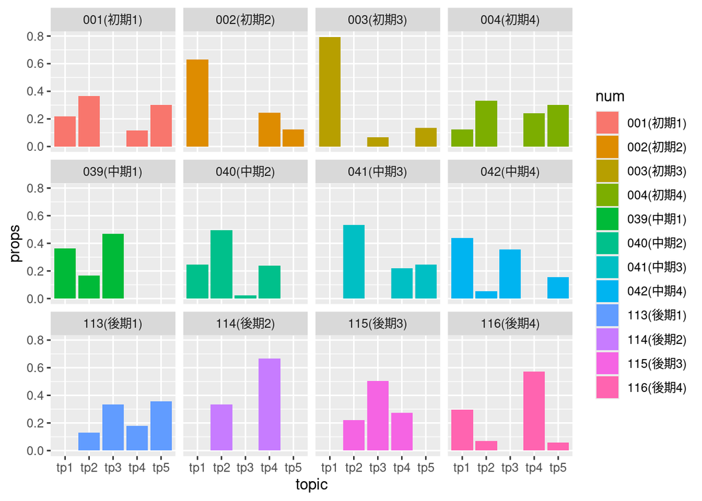

```r
# install.packages("tidyr")

library(tidyr)
backnumber_songsDF <- backnumber_songsDF %>%
                   gather(key = topic, value = props, -num)

library(ggplot2)

backnumber_songsDF %>% ggplot(aes(x = topic, y = props, fill = num)) +       geom_bar(stat = "identity") + facet_wrap(~num)
```

最後に、Word2Vecを用いて各トピックの上位語や特徴的な語をベクトル化することで、back numberにとって、それらの語がどの語と近いのかを明らかにする。 - トピック分類の結果とWord2Vecによる類似語算出結果より、リリース時期による曲のテーマの変化を考察し、リサーチクエスチョン2検証する。